# Lewis Carroll and Alice’s Adventure

Leanne Fortney

April 11, 2017

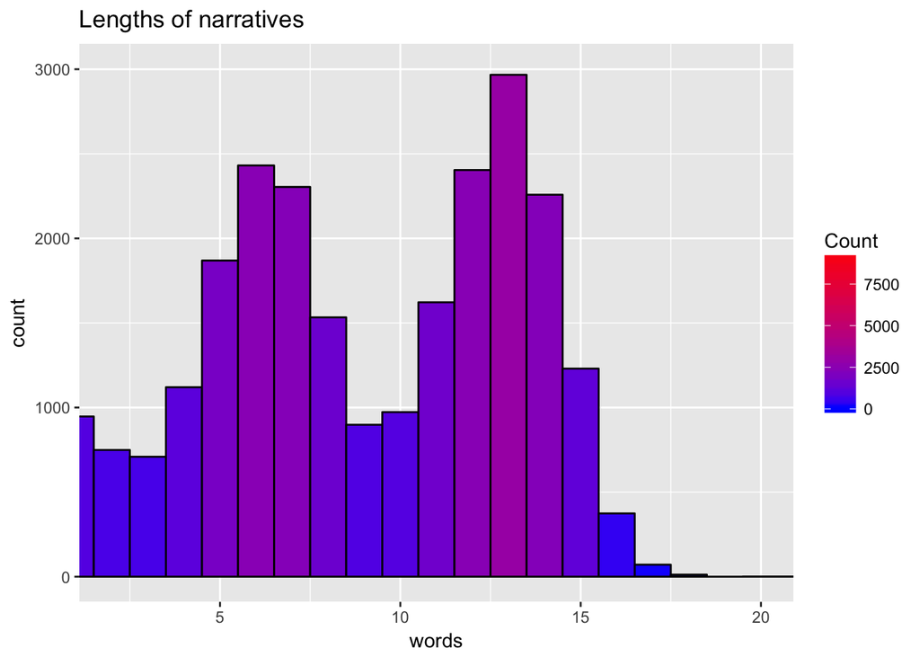

Visualization 2: The Top Ten Words Based on the text provided by the Gutenburg Project I was able to analyze and plot the top ten most popular words from her collection of writings. Not very shocking, but the top three come from her most popular books “Alice’s Adventures in Wonderland” and “Sylvie and Bruno”. What does suprise me is the quantities in which numbers were used in the books. This could be errors from the transcriptions of the books into the Gutenburg Project or it could be the usuage of footnotes, though this wouldn’t account for the use of the number 0.

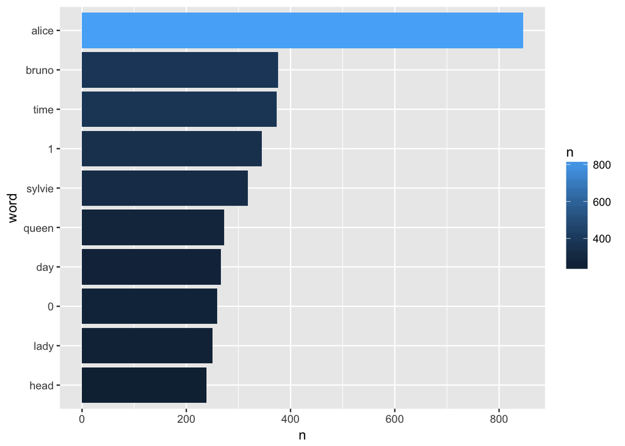

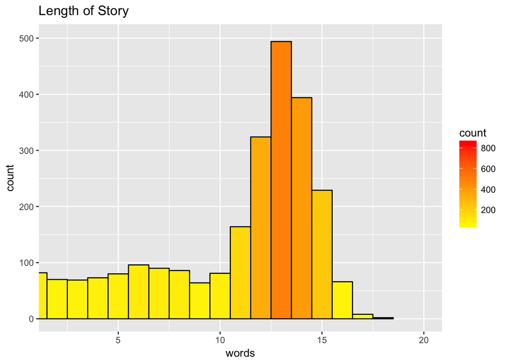

If we take a closer look at the word usuage, it is clearly illustrated that the word Alice recieves the most attention throughout the book. Given this is the name of the primary charactor, this is an accuarate assumption to recieving a higher the average result. The second and third highest used words are “time” and “queen”. These highlight the overall theme of the story, a race to get home before the queen cuts off her head.

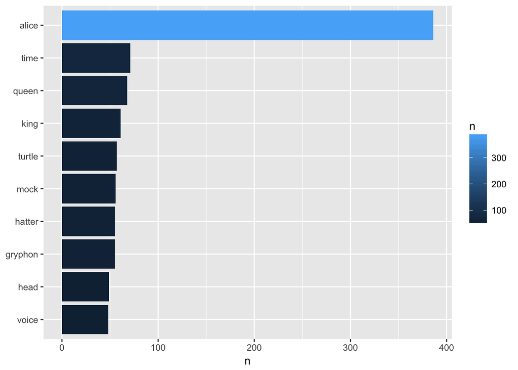

We can also compare “Alice’s Adventures in Wonderland” with “Through the Looking Glass” for any commonalities. With a sample size and low threshhold, at a .72 accuracy, we assess the two books.

```
## [1] 0.7247797
```

When comparing for similarities between “Alice’s Adventures” and “Through the looking glass”, we have the following results. Not even close to 1% of the text.

```
## [1] 0.003025828
```

```
##    12 11
## 12 NA  0
## 11 NA NA
```

```
## TextReuse alignment
## Alignment score: 27
## Document A:
## with a teacup ### ## ### in one hand and a piece of bread and butter in
## the other
##
## Document B:
## with a ###### cup of tea in one hand and a piece of bread and butter in
## the other
```